# Preprocess MOB data for cell type deconvolution

Ningshan Li & Jiayi Zhao

2023/03/19

In this R Notebook we preprocess spatial and corresponding reference scRNA-seq data of mouse olfactory bulb (**MOB**) for cell type deconvolution.

1. **Spatial data preprocessing**:

   1.1 Input original data files
   - Raw nUMI of spatial spots: Rep12_MOB_count_matrix-1.tsv, downloaded from [Spatial Research website](https://www.spatialresearch.org/resources-published-datasets/doi-10-1126science-aaf2403/), and sample **MOB Replicate 12** is selected for analysis.

   1.2 Output data files for cell type deconvolution
   - Raw nUMI of spatial spots: MOB_spatial_spot_nUMI.csv. **No filtering on spots or genes**, i.e. all spots and genes are preserved.
   - Physical location of spatial spots: MOB_spatial_spot_loc.csv. Directly extract the spatial `x` and `y` coordinates from spot names, followed by **rounding to nearest integers**.
   - Adjacency Matrix: MOB_spatial_spot_adjacency_matrix.csv. Spots within neighborhood are adjacent **left**, **right**, **top** and **bottom** spots.
2. **Reference scRNA-seq data preprocessing**:

   2.1 Input original data files

   scRNA-seq data are downloaded from GSE121891.
   - Raw nUMI of all 52,549 single cells: [GSE121891_OB_6_runs.raw.dge.csv.gz](https://www.ncbi.nlm.nih.gov/geo/download/?acc=GSE121891&format=file&file=GSE121891%5FOB%5F6%5Fruns%2Eraw%2Edge%2Ecsv%2Egz)
   - Meta data for 21,746 **Neurons** cells: [GSE121891_Figure_2_metadata.txt.gz](https://www.ncbi.nlm.nih.gov/geo/download/?acc=GSE121891&format=file&file=GSE121891%5FFigure%5F2%5Fmetadata%2Etxt%2Egz)

   2.2 Output data files for cell type deconvolution
   - Raw nUMI of 12,801 cells with selected 5 cell types and 18,560 genes: MOB_ref_scRNA_cell_nUMI.csv.gz. **NO filtering on cells or genes**, i.e. all genes and cells with those 5 cell types are included for analysis.
   - Cell type annotation for those 12,801 cells: MOB_ref_scRNA_cell_celltype.csv

# 1 Version

```r
version[['version.string']]
```

```
[1] "R version 4.2.2 Patched (2022-11-10 r83330)"
```

# 2 Proprocess MOB spatial dataset

## 2.1 Read original data file Rep12_MOB_count_matrix-1.tsv

```r
file_name = file.path(home.dir, 'Rep12_MOB_count_matrix-1.tsv')
org_data = read.csv(file_name, sep = '\t', check.names = F, header = T, row.names = 1)
print(sprintf('load data from %s', file_name))
```

```
[1] "load data from /home/hill103/Documents/SharedFolder/ToHost/CVAE-GLRM_Analysis/RealData/MOB/Rep12_MOB_count_matrix-1.tsv"
```

```r
print(sprintf('spots: %d; genes: %d', nrow(org_data), ncol(org_data)))
```

```
[1] "spots: 282; genes: 16034"
```

```r
org_data[1:5, 1:5]
```

|  | Plekha1 | Cnih3 | Gpc5 | Sirt3 | Rab8a |
| --- | --- | --- | --- | --- | --- |
| 16.918x16.996 | 5 | 1 | 1 | 2 | 5 |
| 18.017x17.034 | 1 | 1 | 0 | 1 | 1 |
| 20.075x17.059 | 0 | 1 | 0 | 0 | 0 |
| 18.979x17.065 | 0 | 0 | 0 | 0 | 0 |
| 21.937x16.967 | 1 | 0 | 0 | 0 | 1 |

## 2.2 Save files for deconvolution

### 2.2.1 Spatial spot nUMI

**No filtering on spots or genes**, directly save all spots and genes into file MOB_spatial_spot_nUMI.csv. **Rows as spatial spots and columns as genes**.

```r
write.csv(org_data, 'MOB_spatial_spot_nUMI.csv')
print(sprintf('save %d gene nUMIs of %d spatial spots into file %s', ncol(org_data), nrow(org_data), 'MOB_spatial_spot_nUMI.csv'))
```

```
[1] "save 16034 gene nUMIs of 282 spatial spots into file MOB_spatial_spot_nUMI.csv"
```

### 2.2.2 Physical Locations of spatial spots

Directly extract the spatial `x` and `y` coordinates from spot names, followed by **rounding to nearest integers**, then saved into file MOB_spatial_spot_loc.csv.

```r
local_df = data.frame(names = row.names(org_data), row.names = row.names(org_data))
local_df = local_df %>%
  tidyr::separate_wider_delim(names, 'x', names = c('x', 'y'))
local_df = as.data.frame(local_df)
row.names(local_df) = row.names(org_data)

local_df['x'] = round(as.numeric(local_df$x))
local_df['y'] = round(as.numeric(local_df$y))

local_df[1:5, ]
```

|  | x | y |
| --- | --- | --- |
| 16.918x16.996 | 17 | 17 |
| 18.017x17.034 | 18 | 17 |
| 20.075x17.059 | 20 | 17 |
| 18.979x17.065 | 19 | 17 |
| 21.937x16.967 | 22 | 17 |

```r
write.csv(local_df, 'MOB_spatial_spot_loc.csv')
print(sprintf('save Physical Locations of spatial spots into file %s', 'MOB_spatial_spot_loc.csv'))
```

```
[1] "save Physical Locations of spatial spots into file MOB_spatial_spot_loc.csv"
```

### 2.2.3 Adjacency Matrix of spatial spots

We define the neighborhood of a spatial spot contains the adjacent **left**, **right**, **top** and **bottom** spot, that is, one spot has at most 4 neighbors.

The generated Adjacency Matrix `A` only contains **1** and **0**, where 1 represents corresponding two spots are adjacent spots according to the definition of neighborhood, while value 0 for non-adjacent spots. Note **all diagonal entries are 0s**.

Adjacency Matrix are saved into file MOB_spatial_spot_adjacency_matrix.csv.

```r
getNeighbour = function(array_row, array_col) {
  # based on the (row, col) of one spot, return the (row, col) of all 4 neighbours
  return(list(c(array_row-1, array_col),
              c(array_row+1, array_col),
              c(array_row+0, array_col-1),
              c(array_row+0, array_col+1)))
}

# adjacency matrix
A = matrix(0, nrow = nrow(local_df), ncol = nrow(local_df))
row.names(A) = rownames(local_df)
colnames(A) = rownames(local_df)
for (i in 1:nrow(local_df)) {
  barcode = rownames(local_df)[i]
  array_row = local_df[i, 'y']
  array_col = local_df[i, 'x']

  # get neighbors
  neighbours = getNeighbour(array_row, array_col)

  # fill the adjacency matrix
  for (this.vec in neighbours) {
    tmp.p = rownames(local_df[local_df$y==this.vec[1] & local_df$x==this.vec[2], ])

    if (length(tmp.p) >= 1) {
      # target spots have neighbors in selected spots
      for (neigh.barcode in tmp.p) {
        A[barcode, neigh.barcode] = 1
      }
    }
  }
}

A[1:5, 1:5]
```

```
              16.918x16.996 18.017x17.034 20.075x17.059 18.979x17.065 21.937x16.967
16.918x16.996             0             1             0             0             0
18.017x17.034             1             0             0             1             0
20.075x17.059             0             0             0             1             0
18.979x17.065             0             1             1             0             0
21.937x16.967             0             0             0             0             0
```

```r
write.csv(A, 'MOB_spatial_spot_adjacency_matrix.csv')
print(sprintf('save Adjacency Matrix of spatial spots into file %s', 'MOB_spatial_spot_adjacency_matrix.csv'))
```

```
[1] "save Adjacency Matrix of spatial spots into file MOB_spatial_spot_adjacency_matrix.csv"
```

Plot Adjacency Matrix. Each node is spot, spots within neighborhood are connected with edges.

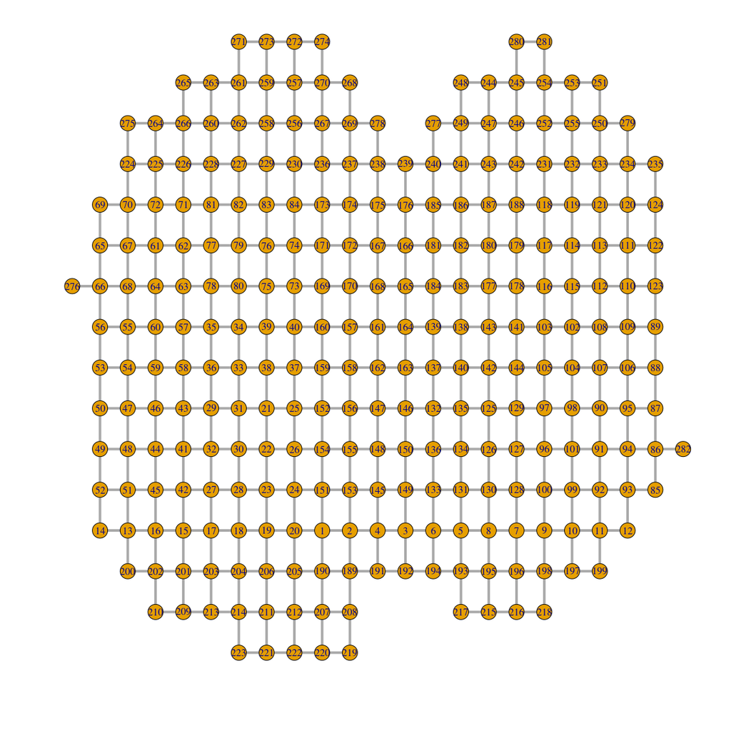

```r
g = graph_from_adjacency_matrix(A, 'undirected', add.colnames = NA, add.rownames = NA)
# manually set nodes x and y coordinates
vertex_attr(g, name = 'x') = local_df$x
vertex_attr(g, name = 'y') = local_df$y
plot(g, vertex.size=5, edge.width=4, margin=-0.05)
```

# 3 Proprocess reference scRNA-seq data

## 3.1 Read and preprocess scRNA-seq meta data

Original meta data file is [GSE121891_Figure_2_metadata.txt.gz](https://www.ncbi.nlm.nih.gov/geo/download/?acc=GSE121891&format=file&file=GSE121891%5FFigure%5F2%5Fmetadata%2Etxt%2Egz) downloaded from GSE121891. It contains meta data of 21,746 **Neurons** cells from mouse olfactory bulb. The cell type annotation is stored in column `FinalIds`, which includes total 18 distinct annotations. We selected 5 cell types and combine the subtypes as below:

1. granule cells (**GC**): “n03-GC-1” + “n07-GC-2” + “n09-GC-3” + “n10-GC-4” + “n11-GC-5” + “n12-GC-6” + “n14-GC-7”
2. olfactory sensory neurons (**OSNs**): “n01-OSNs”
3. periglomerular cells (**PGC**): “n02-PGC-1” + “n05-PGC-2” + “n08-PGC-3”
4. mitral and tufted cells (**M/TC**): “n15-M/TC-1” + “n16-M/TC-2” + “n17-M/TC-3”
5. external plexiform layer interneurons (**EPL-IN**): “n18-EPL-IN”

3 Subtypes “n04-Immature”, “n06-Transition” and “n13-AstrocyteLike” are discarded.

**NO further filtering on cells**, i.e. all 12,801 cells of these 5 selected cell types will be used for cell type deconvolution.

```r
file_name = file.path(home.dir, 'GSE121891_Figure_2_metadata.txt.gz')
ref_meta = read.csv(gzfile(file_name), sep='\t', check.names = F, header = T, row.names = 1)
print(sprintf('load data from %s', file_name))
```

```
[1] "load data from /home/hill103/Documents/SharedFolder/ToHost/CVAE-GLRM_Analysis/RealData/MOB/GSE121891_Figure_2_metadata.txt.gz"
```

```r
print(sprintf('total %d cells with distinct %d cell type annotations', nrow(ref_meta), length(unique(ref_meta$FinalIds))))
```

```
[1] "total 21746 cells with distinct 18 cell type annotations"
```

```r
# remove unwanted 3 subtypes
ref_meta = ref_meta[ref_meta$FinalIds %notin% c("n04-Immature", "n06-Transition", "n13-AstrocyteLike"), ]
print(sprintf('remove 3 cell subtype annotations, remain %d cells', nrow(ref_meta)))
```

```
[1] "remove 3 cell subtype annotations, remain 12801 cells"
```

```r
# combine subtypes
ref_meta$celltype = ""
ref_meta[ref_meta$FinalIds %in% c("n03-GC-1", "n07-GC-2", "n09-GC-3", "n10-GC-4", "n11-GC-5", "n12-GC-6", "n14-GC-7"), "celltype"] = "GC"
ref_meta[ref_meta$FinalIds == "n01-OSNs", "celltype"] = "OSNs"
ref_meta[ref_meta$FinalIds %in% c("n02-PGC-1", "n05-PGC-2", "n08-PGC-3"), "celltype"] = "PGC"
ref_meta[ref_meta$FinalIds %in% c("n15-M/TC-1", "n16-M/TC-2", "n17-M/TC-3"), "celltype"] = "M/TC"
ref_meta[ref_meta$FinalIds == "n18-EPL-IN", "celltype"] = "EPL-IN"

table(ref_meta$celltype)
```

```
EPL-IN     GC   M/TC   OSNs    PGC
   161   8614   1133   1200   1693
```

```r
ref_meta[1:5, c('FinalIds', 'celltype')]
```

|  | FinalIds | celltype |
| --- | --- | --- |
| WT1_AAACCTGAGCTGCGAA | n03-GC-1 | GC |
| WT1_AAACCTGGTTTGGCGC | n03-GC-1 | GC |
| WT1_AAACGGGAGATCCGAG | n03-GC-1 | GC |
| WT1_AAACGGGGTAAGTGGC | n03-GC-1 | GC |
| WT1_AAATGCCAGGCATGGT | n03-GC-1 | GC |

Save cell type annotation to file MOB_ref_scRNA_cell_celltype.csv

```r
write.csv(ref_meta[, 'celltype', drop=F], 'MOB_ref_scRNA_cell_celltype.csv')
print(sprintf('save cell type annotation of reference scRNA-seq cells into file %s', 'MOB_ref_scRNA_cell_celltype.csv'))
```

```
[1] "save cell type annotation of reference scRNA-seq cells into file MOB_ref_scRNA_cell_celltype.csv"
```

## 3.2 Read and preprocess scRNA-seq nUMI data

Original gene nUMI count data file is [GSE121891_OB_6_runs.raw.dge.csv.gz](https://www.ncbi.nlm.nih.gov/geo/download/?acc=GSE121891&format=file&file=GSE121891%5FOB%5F6%5Fruns%2Eraw%2Edge%2Ecsv%2Egz) downloaded from GSE121891. It contains total 52,549 cells and 18,560 genes.

We just selected 12,801 cells of the 5 selected cell types by barcodes, and discard other cells. **NO filtering on genes**, i.e. all 18,560 genes will be used for cell type deconvolution.

```r
file_name = file.path(home.dir, 'GSE121891_OB_6_runs.raw.dge.csv.gz')
ref_data = data.table::fread(file_name, sep = ",", check.names = FALSE, select = c('V1', row.names(ref_meta)))
gene_names = ref_data$V1

# transpose it
ref_data = as.data.frame(data.table::transpose(ref_data %>%
  select(row.names(ref_meta))))

row.names(ref_data) = row.names(ref_meta)
colnames(ref_data) = gene_names

print(sprintf('load data from %s', file_name))
```

```
[1] "load data from /home/hill103/Documents/SharedFolder/ToHost/CVAE-GLRM_Analysis/RealData/MOB/GSE121891_OB_6_runs.raw.dge.csv.gz"
```

```r
print(sprintf('cells: %d; genes: %d', nrow(ref_data), ncol(ref_data)))
```

```
[1] "cells: 12801; genes: 18560"
```

```r
ref_data[1:5, 1:5]
```

|  | Xkr4 | Gm1992 | Rp1 | Sox17 | Mrpl15 |
| --- | --- | --- | --- | --- | --- |
| WT1_AAACCTGAGCTGCGAA | 0 | 0 | 0 | 0 | 1 |
| WT1_AAACCTGGTTTGGCGC | 0 | 0 | 0 | 0 | 0 |
| WT1_AAACGGGAGATCCGAG | 0 | 0 | 0 | 0 | 0 |
| WT1_AAACGGGGTAAGTGGC | 0 | 0 | 0 | 0 | 0 |
| WT1_AAATGCCAGGCATGGT | 0 | 0 | 0 | 0 | 0 |

Save scRNA-seq nUMI matrix to file MOB_ref_scRNA_cell_nUMI.csv.gz

```r
data.table::fwrite(ref_data, 'MOB_ref_scRNA_cell_nUMI.csv.gz', row.names = T)
print(sprintf('save nUMI matrix of reference scRNA-seq cells into gzip compressed file %s', 'MOB_ref_scRNA_cell_nUMI.csv.gz'))
```

```
[1] "save nUMI matrix of reference scRNA-seq cells into gzip compressed file MOB_ref_scRNA_cell_nUMI.csv.gz"
```